# Penguin Plots

Bryan Murphy

2023-03-28

Ctrl+Alt+I

```r
print("This is what you get")
```

```
## [1] "This is what you get"
```

# Google Activity

[This is what I’m following](https://www.coursera.org/learn/data-analysis-r/quiz/ktFaF/hands-on-activity-your-r-markdown-notebook/attempt)

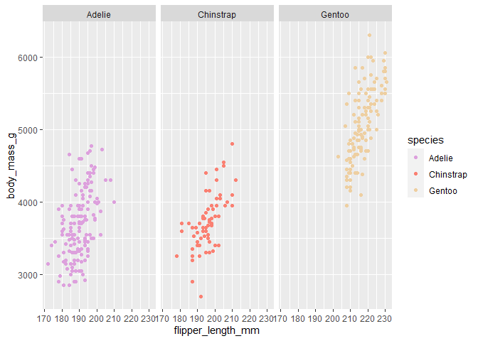

```r
# We added warning = FALSE because IDC that you removed two outlier rows and neither would the person reading this

ggplot(data = penguins, mapping = aes(x=flipper_length_mm, y=body_mass_g)) +
      geom_point(aes(color = species)) +
      scale_color_manual(values = c("plum", "salmon", "navajowhite2")) +
      facet_wrap(~species)
```

# This is my prettiest graph

```
This does not work even though it should

---
<center>

#This is my prettiest graph

</center>
---

This does work, as you'll see below:

<h1 align="center">This is my prettiest graph</h1>
```

# **This** is *my* prettiest *graph*

[figure not shown]

```r
with(diamonds, table(cut,clarity))
```

```
##            clarity
## cut           I1  SI2  SI1  VS2  VS1 VVS2 VVS1   IF
##   Fair       210  466  408  261  170   69   17    9
##   Good        96 1081 1560  978  648  286  186   71
##   Very Good   84 2100 3240 2591 1775 1235  789  268
##   Premium    205 2949 3575 3357 1989  870  616  230
##   Ideal      146 2598 4282 5071 3589 2606 2047 1212
```

From here on out, I’m following [this link](https://www.coursera.org/learn/data-analysis-r/lecture/ix21Z/structure-of-markdown-documents)

Okay:

In RMarkdown, you can create the following types of files

- HTML
  - They’re cool
- PDF
  - Please don’t make me have to edit these
- .Docx files
  - Proprietary but I like it TBH
    - Does this work too?
      - Every two spaces is a new indentation
1. HTML
- Please don’t make me have to
  - Edit these

[figure not shown]

Vibe check

| First Header | Second Header |
| --- | --- |
| Content Cell | Content Cell |
| Content Cell | Content Cell |

| Why does this break so badly for me | Second Header |
| --- | --- |
| Content Cell | Content Cell |
| Content Cell | Content Cell |

Hey  
it worked.

```
Using <br> to insert a link break in a column heading in a table
```

[Now I’m here](https://www.coursera.org/learn/data-analysis-r/quiz/5N6hc/hands-on-activity-adding-code-chunks-to-r-markdown-notebooks/attempt)

```r
library(ggplot2)

library(palmerpenguins)

data(penguins)

View(penguins)
```

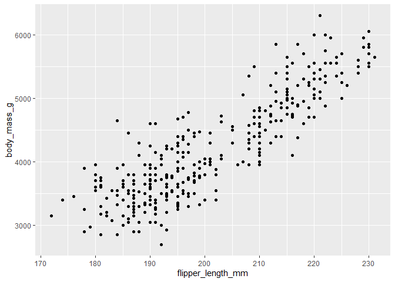

```r
ggplot(data = penguins) +

  geom_point(mapping = aes(x = flipper_length_mm, y = body_mass_g))
```

[Output Formats Available in RMarkdown](https://www.coursera.org/learn/data-analysis-r/supplement/BS3Mb/output-formats-in-r-markdown)

- pdf_document – This creates a PDF file with LaTeX (an open source document layout system). If you don’t already have LaTeX, RStudio will automatically prompt you to install it.
- word_document – This creates a Microsoft Word document (.docx).
- odt_document – This creates an OpenDocument Text document (.odt).
- rtf_document – This creates a Rich Text Format document (.rtf).
- md_document – This creates a Markdown document (which strictly conforms to the original Markdown specification)
- github_document – This creates a GitHub document which is a customized version of a Markdown document designed for sharing on GitHub.

  ```
  Saving your report as a html_notebook by changing the parameters in the heading creates a nb.html file that can be opened in a browser as a regular html file OR in RStudio to see the embedded source code as if it was an .rmd file.
  ```

Testing

```
  Testing
```

[Learn More Here - rmarkdown official site](https://rmarkdown.rstudio.com/lesson-10.html)

[Here’s how to create dashboards](https://pkgs.rstudio.com/flexdashboard/articles/flexdashboard.html)

[Shiny seems dope but I’m definitely not getting into that right now](https://shiny.rstudio.com/tutorial/)

[CRAN Download Monitor (shinyapps.io)](https://gallery.shinyapps.io/cran-gauge/) [29 R Markdown formats | R for Data Science (had.co.nz)](https://r4ds.had.co.nz/r-markdown-formats.html)

# R packages with templates

Some popular packages with templates for R Markdown include the following:

The vitae package contains templates for creating and maintaining a résumé or curriculum vitae (CV)

The rticles package provides templates for various journals and publishers

The learnr package makes it easy to turn any R Markdown document into an interactive tutorial

The bookdown package facilitates writing books and long-form articles

The flexdashboard package lets you publish a group of related data visualizations as a dashboard

# # More formatting examples

Hunt’s Tomato Ketchup is the best

Everyone knows Heinz<sup>2</sup> tomato ketchup is the best

Everyone knows curry<sub>2</sub> ketchup is the best

Do I need to actually type superscript<sup>2</sup> to make it work?

Or type out subscript<sub>2</sub> to make it work?

Actually it’s putting <sup>your</sup> <sup>text</sup> <sup>between</sup> <sup>carrots</sup> such as ^ that makes it superscript

Putting it between <sub>tildes</sub> <sub>like</sub> <sub>this</sub> makes it subscript

You have to put the ^ or ~ around every single word

# One hashtag

## Two hashtags

### Three hashtags

#### Four hashtags after a line break

##### Five hashtags

###### Six hashtags

Seven hashtags is too many it looks like

And so is 8 hashtags

Hunt’s Tomato Ketchup is the best

*One asterisk is italics.*

**Two is bold.**

*Three is both*

Everyone knows Heinz<sup>2</sup> tomato ketchup is the best

Everyone knows curry<sub>2</sub> ketchup is the best

Do I need to actually type superscript<sup>2</sup> to make it work?

Or type out subscript<sub>2</sub> to make it work?

Actually it’s putting <sup>your</sup> <sup>text</sup> <sup>between</sup> <sup>carrots</sup> such as ^ that makes it superscript

Putting it between <sub>tildes</sub> <sub>like</sub> <sub>this</sub> makes it subscript

You have to put the ^ or ~ around every single word

```
  If you start typing when indented you get a
  Block like
  this
```

```
If you start typing in a code block without {r}, you can basically make comments.
```

I’m not sure if

> this block quote looks different than  
> what you get if you type after an indent  
> > Not sure if two arrows does anything either

Here’s some latex: $A^2 + B^2 = C^2$

Inline code is like `Hello world` or 50 cars studied